# Simulations OVB/type M trade-off: IV

Vincent Bagilet https://vincentbagilet.github.io/ (Columbia University)https://www.columbia.edu/  
2021-11-05

## Purpose of the document

In this document, I run a simulation exercise to illustrate issues arising when estimating Two-Way Fixed Effect (TWFE) models with staggered and heterogeneous treatment.

First, I load useful packages. Note that some packages are optional. If you do not want to install/use them, you may need to modify part of your code. `mediocrethemes` is my ggplot theme package. If you want to use it, you can find instructions [here](https://vincentbagilet.github.io/mediocrethemes/).

```r
#necessary packages
library(tidyverse)
library(fixest)
library(knitr)
library(broom)

#Optional packages
library(mediocrethemes)
library(tictoc)
library(here)
library(beepr)

set.seed(1)

mediocrethemes::set_mediocre_all(pal = "coty")
```

## Building the example

To illustrate issues arising with TWFE, I build simple fake data, estimate a TWFE model on it and replicate the analysis several times.

### Modelisation choices

To simplify, I consider the assumptions described below. Of course these assumptions are purely arbitrary and I invite you to play with them. Note that, fixed effects and the covariate are not necessary to the analysis. I only add them to make the analysis more realistic if necessary but I set their baseline values to 0.

- Each individual has fixed characteristics drawn from a normal distribution,
- Each time period presents fixed characteristics also drawn from a normal distribution,
- A unique covariate $x$ drawn from a normal distribution,
- A proportion $p_{treat}$ of individuals are ever treated over the period. Hence, a proportion of $1-p_{treat}$ individuals are never treated over the period. I draw these individual at random. Note that the value of the individual identifiers do not matter here. So I could assume that the non-treated individuals are those with the larger individual ids for instance,
- The implementation of the treatment can be staggered or not. If it is not staggered, the treatment date is set to be in the middle of the period
- The treatment can vary along two dimensions, time and individual. Details are given below.

I also create a bunch of variables that can be useful: - $InTreatment_i$ equal to 1 if individual $i$ ever gets treated, - $t^{event}_i$ equal to the date at which individual $i$ gets treated, - $t^{centered}_i$ representing the distance in terms of period to the beginning of the treatment for individual $i$, - $Post_{it}$ equal to 1 if the period $t$ is after the treatment has begun for individual $i$. This variable is only useful for non-staggered treatment allocation,

### Data generation

I write a simple function that generates the data. It takes as input the values of the different parameters and returns a data frame containing all the variables for this analysis.

```r
generate_data_TWFE <- function(N_i,
                               N_t,
                               sigma_e,
                               p_treat,
                               staggered,
                               het_indiv,
                               het_time,
                               alpha,
                               beta,
                               mu_indiv_fe = 0,
                               sigma_indiv_fe = 0,
                               mu_time_fe = 0,
                               sigma_time_fe = 0,
                               mu_x = 0,
                               sigma_x = 0,
                               gamma = 0
                             ) {

  if (!is.logical(staggered)) {stop("staggered must be logical")}
  if (!(het_indiv %in% c("large_first", "random", "homogeneous"))) {
    stop('het_indiv must be either "large_first", "random" or "homogeneous"')
  }
  if (!(het_time %in% c("constant", "linear"))) {
    stop('het_time must be either "constant" or "linear"')
  }

  data <- tibble(indiv = 1:N_i) %>%
    mutate(in_treatment = (indiv %in% sample(1:N_i, floor(N_i*p_treat)))) %>%
    crossing(t = 1:N_t) %>%
    group_by(indiv) %>%
    mutate(
      indiv_fe = rnorm(1, mu_indiv_fe, sigma_indiv_fe),
      t_event = ifelse(staggered, sample(2:(N_t - 1), 1), floor(N_t/2)),
        #I use 2:(N_t-1) to have a pre and post period
      t_event = ifelse(in_treatment, t_event, NA),
      beta_i = case_when(
        het_indiv == "large_first" ~ N_t-t_event,
        het_indiv == "random" ~ runif(1, beta*0.5, beta*1.5),
        het_indiv == "homogeneous" ~ beta
      ),
      beta_i = ifelse(is.na(t_event), 0, beta_i)
    ) %>%
    ungroup() %>%
    group_by(t) %>%
    mutate(time_fe = rnorm(1, mu_time_fe, sigma_time_fe)) %>%
    ungroup() %>%
    mutate(
      post = (t > t_event),
      treated = in_treatment & post,
      beta_i = ifelse(
        het_time == "linear" & post & !is.na(t_event),
        beta_i*(t - t_event),
        beta_i
      ),
      t_centered = t - t_event,
      x = rnorm(nrow(.), mu_x, sigma_x),
      e = rnorm(nrow(.), 0, sigma_e),
      y0 = alpha + gamma * x + indiv_fe + time_fe + e,
      y1 = y0 + beta_i,
      y = treated*y1 + (1 - treated)*y0
    )

  return(data)
}
```

I set baseline values for the parameters as very standard. These values are completely arbitrary.

```r
baseline_parameters_TWFE <- tibble(
  N_i = 20,
  N_t = 50,
  sigma_e = 1,
  p_treat = 0.8,
  staggered = TRUE,
  het_indiv = "homogeneous",
  het_time = "constant",
  alpha = 1,
  beta = 1
)
```

Here is an example of data created with the data generating process and baseline parameter values, for 2 individuals and 8 time periods:

| indiv | t | y | in_treatment | post | treated | t_centered | e |
| --- | --- | --- | --- | --- | --- | --- | --- |
| 1 | 1 | 2.5952808 | TRUE | FALSE | FALSE | -4 | 1.5952808 |
| 1 | 2 | 1.3295078 | TRUE | FALSE | FALSE | -3 | 0.3295078 |
| 1 | 3 | 0.1795316 | TRUE | FALSE | FALSE | -2 | -0.8204684 |
| 1 | 4 | 1.4874291 | TRUE | FALSE | FALSE | -1 | 0.4874291 |
| 1 | 5 | 1.7383247 | TRUE | FALSE | FALSE | 0 | 0.7383247 |
| 1 | 6 | 2.5757814 | TRUE | TRUE | TRUE | 1 | 0.5757814 |
| 1 | 7 | 1.6946116 | TRUE | TRUE | TRUE | 2 | -0.3053884 |
| 1 | 8 | 3.5117812 | TRUE | TRUE | TRUE | 3 | 1.5117812 |
| 2 | 1 | 1.3898432 | FALSE | NA | FALSE | NA | 0.3898432 |
| 2 | 2 | 0.3787594 | FALSE | NA | FALSE | NA | -0.6212406 |
| 2 | 3 | -1.2146999 | FALSE | NA | FALSE | NA | -2.2146999 |
| 2 | 4 | 2.1249309 | FALSE | NA | FALSE | NA | 1.1249309 |
| 2 | 5 | 0.9550664 | FALSE | NA | FALSE | NA | -0.0449336 |
| 2 | 6 | 0.9838097 | FALSE | NA | FALSE | NA | -0.0161903 |
| 2 | 7 | 1.9438362 | FALSE | NA | FALSE | NA | 0.9438362 |
| 2 | 8 | 1.8212212 | FALSE | NA | FALSE | NA | 0.8212212 |

Let’s now have a look at different types of treatment and treatment allocations. First, let’s look at treatment allocation mechanisms. The allocation can either be staggered or not

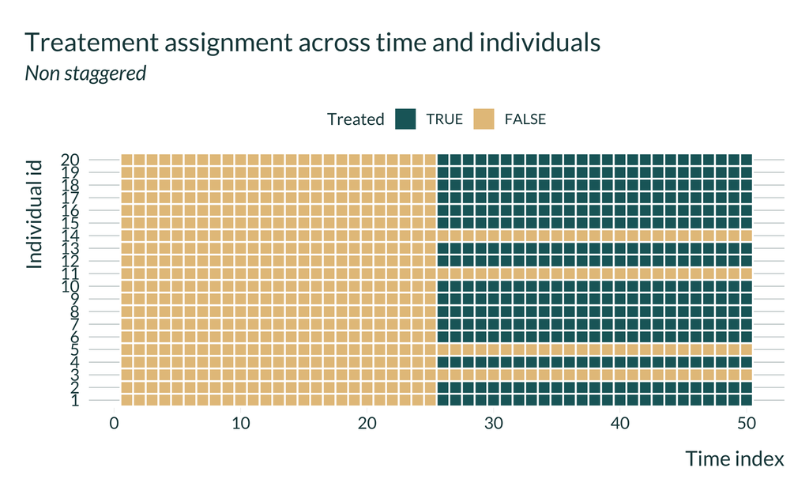

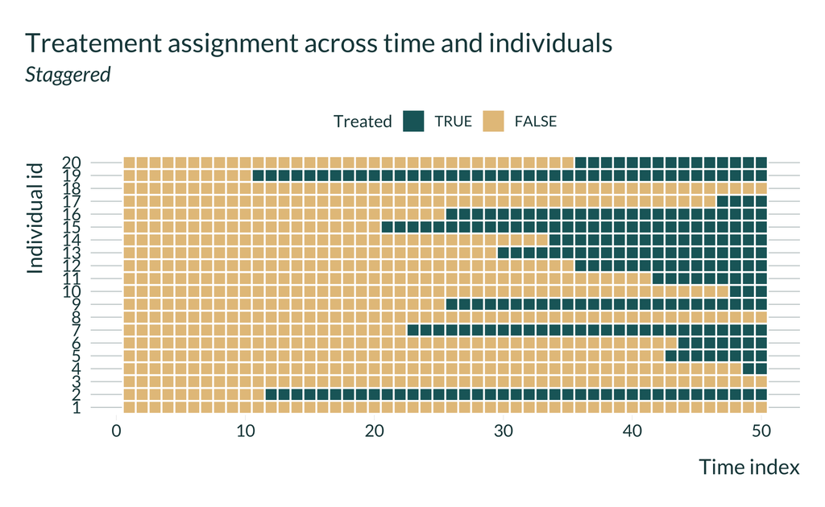

Now, let’s vary treatment effect size across individuals, considering a staggered adoption.

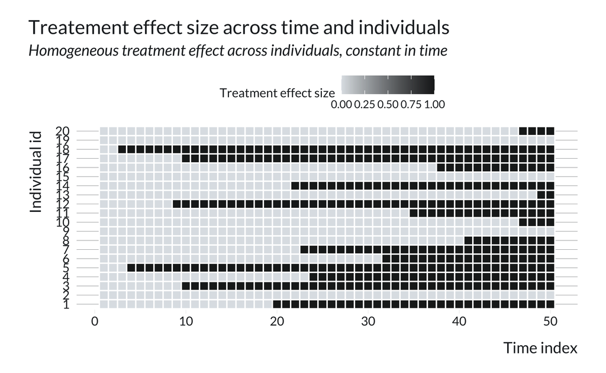

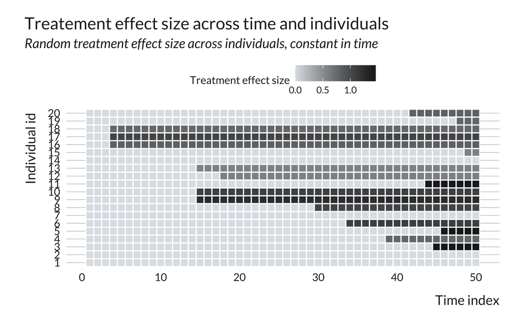

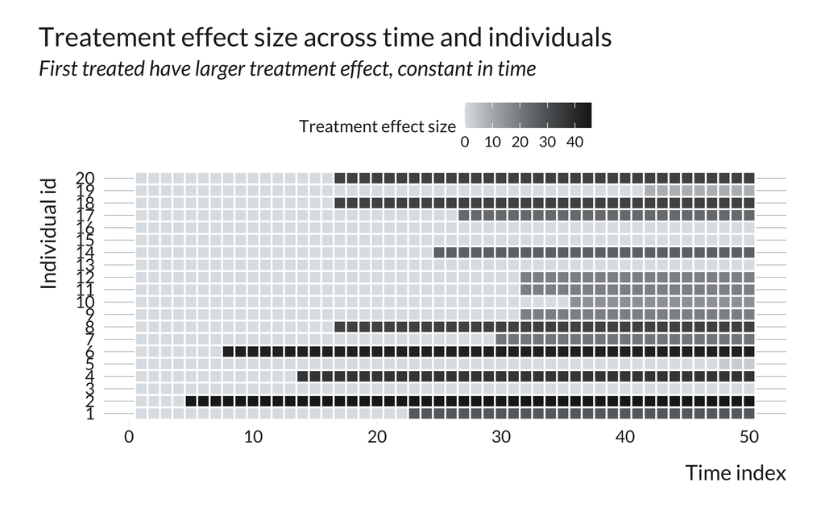

A last thing we can vary is that we can make individual effects increase linearly in time.

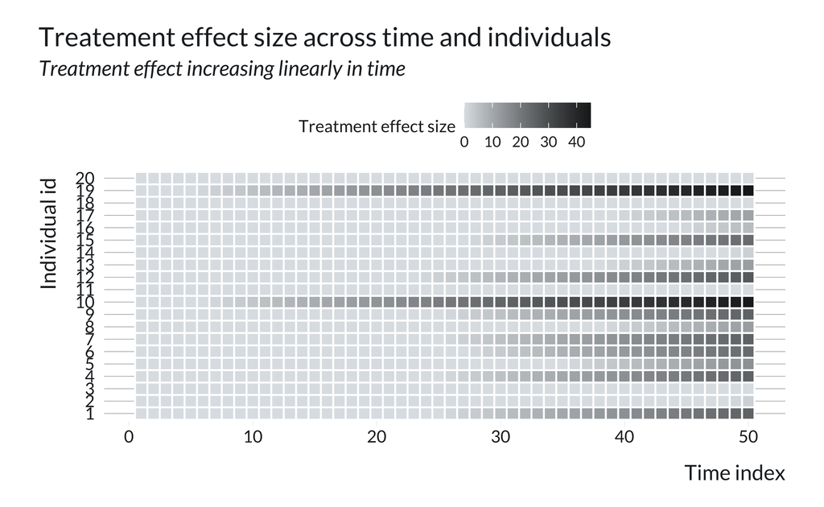

### Estimation

After generating the data, we can run an estimation.

```r
estimate_TWFE <- function(data) {
  reg <- data %>%
    mutate(
      indiv = as.factor(indiv),
      t = as.factor(t),
      treated = as.numeric(treated),
      in_treatment = as.numeric(in_treatment),
      t_centered = as.factor(t_centered)
    ) %>%
    feols(
    data = .,
    fml = y ~ in_treatment:t_centered | indiv + t
    ) %>%
    broom::tidy() %>%
    rename(p_value = p.value, se = std.error) %>%
    mutate(term = as.numeric(str_remove_all(term, "in_treatment\\:t_centered"))) %>%
    rename(lag = term)

  return(reg)
}
```

```r
baseline_parameters_TWFE %>%
  pmap_dfr(generate_data_TWFE) %>%
  estimate_TWFE()
```

```
# A tibble: 94 x 5
     lag estimate    se statistic p_value
   <dbl>    <dbl> <dbl>     <dbl>   <dbl>
 1   -47     48.4  72.5     0.667   0.515
 2   -46     48.5  71.8     0.676   0.509
 3   -45     47.2  71.0     0.666   0.516
 4   -44     47.4  70.2     0.676   0.510
 5   -43     47.4  69.6     0.681   0.506
 6   -42     45.0  68.7     0.654   0.523
 7   -41     46.0  67.9     0.676   0.509
 8   -40     44.8  67.1     0.667   0.515
 9   -39     44.4  66.5     0.668   0.514
10   -38     43.9  65.6     0.669   0.514
# … with 84 more rows
```

### Run a whole simulation

To do so I create the function `compute_simulation_TWFE`. This simple function takes as input the various parameters an returns a table with the estimate of the treatment, its p-value and standard error and all input parameters.

But first, we want to compute the true effect (the ATT) to add it to our output.

```r
compute_true_effect_TWFE <- function(data) {
  data %>%
    filter(in_treatment) %>%
    group_by(t_centered) %>%
    summarise(true_effect = mean(treated*(y1 - y0))) %>%
    rename(lag = t_centered)
}
```

We can then compute the simulation.

```r
compute_simulation_TWFE <- function(N_i,
                                    N_t,
                                    sigma_e,
                                    p_treat,
                                    staggered,
                                    het_indiv,
                                    het_time,
                                    alpha,
                                    beta,
                                    mu_indiv_fe = 0,
                                    sigma_indiv_fe = 0,
                                    mu_time_fe = 0,
                                    sigma_time_fe = 0,
                                    mu_x = 0,
                                    sigma_x = 0,
                                    gamma = 0) {
  data <- generate_data_TWFE(
    N_i = N_i,
    N_t = N_t,
    sigma_e = sigma_e,
    p_treat = p_treat,
    staggered = staggered,
    het_indiv = het_indiv,
    het_time = het_time,
    alpha = alpha,
    beta = beta,
    mu_indiv_fe = mu_indiv_fe,
    sigma_indiv_fe = sigma_indiv_fe,
    mu_time_fe = mu_time_fe,
    sigma_time_fe = sigma_time_fe,
    mu_x = mu_x,
    sigma_x = sigma_x,
    gamma = gamma
  )

  data %>%
    estimate_TWFE() %>%
    mutate(
      N_i = N_i,
      N_t = N_t,
      sigma_e = sigma_e,
      p_treat = p_treat,
      staggered = staggered,
      het_indiv = het_indiv,
      het_time = het_time,
      alpha = alpha,
      beta = beta,
      mu_indiv_fe = mu_indiv_fe,
      sigma_indiv_fe = sigma_indiv_fe,
      mu_time_fe = mu_time_fe,
      sigma_time_fe = sigma_time_fe,
      mu_x = mu_x,
      sigma_x = sigma_x,
      gamma = gamma
    ) %>%
    left_join(compute_true_effect_TWFE(data), by = "lag")
}
```

Here is the output of one simulation:

```r
baseline_parameters_TWFE %>%
  pmap_dfr(compute_simulation_TWFE)
```

```
# A tibble: 92 x 22
     lag estimate    se statistic p_value   N_i   N_t sigma_e p_treat
   <dbl>    <dbl> <dbl>     <dbl>   <dbl> <dbl> <dbl>   <dbl>   <dbl>
 1   -45   -0.229  2.09    -0.109   0.914    20    50       1     0.8
 2   -44   -1.03   2.01    -0.510   0.617    20    50       1     0.8
 3   -43   -0.476  1.80    -0.265   0.794    20    50       1     0.8
 4   -42   -2.26   1.81    -1.25    0.231    20    50       1     0.8
 5   -41   -0.593  2.02    -0.293   0.774    20    50       1     0.8
 6   -40   -0.376  2.03    -0.185   0.856    20    50       1     0.8
 7   -39   -0.965  1.72    -0.562   0.583    20    50       1     0.8
 8   -38   -2.04   1.94    -1.05    0.309    20    50       1     0.8
 9   -37   -1.26   1.90    -0.661   0.519    20    50       1     0.8
10   -36   -0.265  1.99    -0.133   0.896    20    50       1     0.8
# … with 82 more rows, and 13 more variables: staggered <lgl>,
#   het_indiv <chr>, het_time <chr>, alpha <dbl>, beta <dbl>,
#   mu_indiv_fe <dbl>, sigma_indiv_fe <dbl>, mu_time_fe <dbl>,
#   sigma_time_fe <dbl>, mu_x <dbl>, sigma_x <dbl>, gamma <dbl>,
#   true_effect <dbl>
```

## Analysis of the results

To analyze the results, I build a simple function to run the regression and graph the results. It takes as inputs the baseline parameters and our parameters of interest.

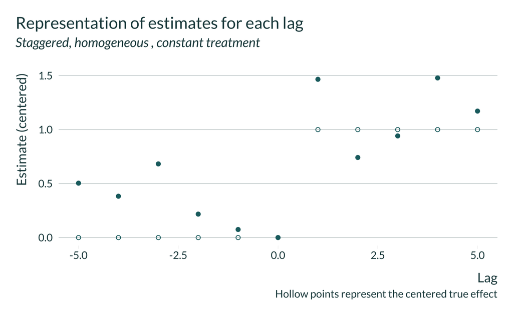

```r
graph_results <- function(baseline_parameters,
                          staggered = TRUE,
                          het_indiv = "homogeneous",
                          het_time = "constant") {

  baseline_parameters["staggered"] <- staggered
  baseline_parameters["het_indiv"] <- het_indiv
  baseline_parameters["het_time"] <- het_time

  graph <- baseline_parameters %>%
    pmap_dfr(compute_simulation_TWFE) %>%
    filter(dplyr::between(lag, -5, 5)) %>%
    mutate(
      estimate_level = (estimate - estimate[which(lag == 0)]),
      true_effect_level = (true_effect - true_effect[which(lag == 0)])
    ) %>%
    ggplot() +
    geom_point(aes(x = lag, y = estimate_level)) +
    geom_point(aes(x = lag, y = true_effect_level), shape = 1) +
    # geom_errorbar(aes(x = lag, ymin=estimate_level-se, ymax=estimate_level+se)) +
    labs(
      x = "Lag",
      y = "Estimate (centered)",
      title = "Representation of estimates for each lag",
      subtitle = paste(
      ifelse(staggered, "Staggered,", "Non staggered,"),
      het_indiv, ",",
      het_time,
      "treatment"),
      caption = "Hollow points represent the centered true effect"
    )

  return(graph)
}

baseline_parameters_TWFE %>%
  graph_results()
```

We can reproduce this graph for varying types of treatment.

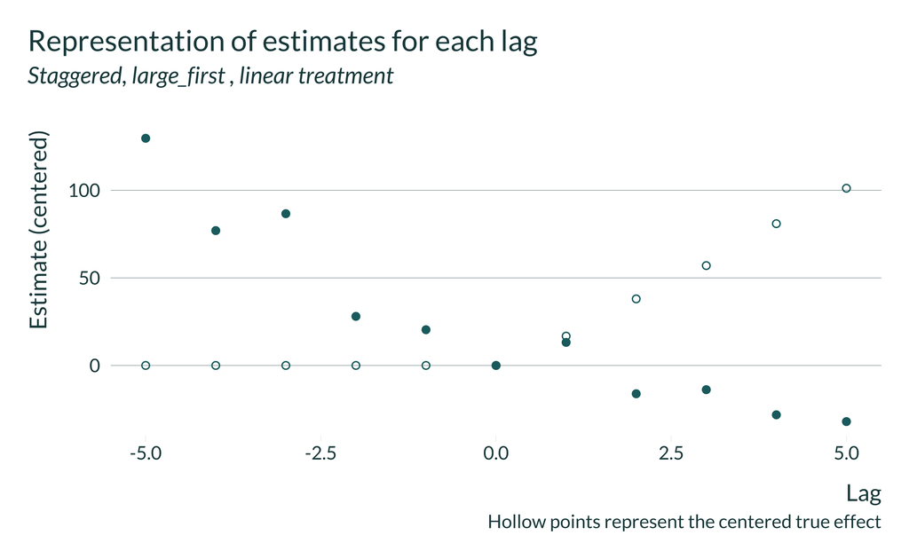

```r
baseline_parameters_TWFE %>%
  graph_results(staggered = TRUE, het_indiv = "large_first", het_time = "linear")
```